# 관광두레 주민공동체 현황분석

한림대학교 이기원

## 자료 구조

### 기초자료

```
## 'data.frame':    97 obs. of  24 variables:
##  $ 조직명      : chr  "수원누리" "수원화성공예_협" "행궁맛촌" "이웃문화협동조합" ...
##  $ 시도        : Factor w/ 8 levels "강원","경기",..: 2 2 2 2 2 2 2 2 2 2 ...
##  $ 시군        : Factor w/ 18 levels "가평","강릉",..: 10 10 10 10 10 12 12 12 12 12 ...
##  $ PD.1        : Factor w/ 18 levels "경용주","권옥선",..: 3 3 3 3 3 11 11 11 11 11 ...
##  $ PD.2        : Factor w/ 3 levels "박호철","없음",..: 1 1 1 1 1 2 2 2 2 2 ...
##  $ 공동체상태  : Factor w/ 2 levels "경영개선","창업준비": 2 2 2 1 2 2 1 2 2 2 ...
##  $ 조직형태    : Factor w/ 2 levels "법인","임의단체": 2 2 2 1 2 2 1 1 1 2 ...
##  $ 조직원      : num  4 4 4 5 5 5 40 67 5 5 ...
##  $ 법인유형    : Factor w/ 7 levels "마을회","사단법인",..: 5 5 5 7 5 5 3 7 3 5 ...
##  $ 설립일      : Date, format: "2014-05-01" "2015-03-01" ...
##  $ 사업자등록  : Factor w/ 49 levels "124-87-43816",..: 49 39 49 1 49 2 3 49 49 49 ...
##  $ 업태        : Factor w/ 16 levels "농업","도소매",..: 16 16 16 5 16 16 16 16 16 16 ...
##  $ 종목        : Factor w/ 30 levels "곡물","공연",..: 30 30 30 11 30 30 30 30 30 30 ...
##  $ 소재지      : Factor w/ 19 levels "가평","강릉",..: 11 11 11 11 11 13 13 13 13 13 ...
##  $ 인적자원    : Factor w/ 3 levels "상","중","하": 3 2 2 1 3 1 3 3 3 3 ...
##  $ 물적자원    : Factor w/ 3 levels "상","중","하": 2 2 2 2 2 1 3 3 3 3 ...
##  $ 재무자원    : Factor w/ 3 levels "상","중","하": 3 3 3 2 3 3 3 3 3 3 ...
##  $ 정부지원사업: num  1 1 1 1 0 0 0 0 0 0 ...
##  $ 사업명      : Factor w/ 33 levels "경기도특화거리지원",..: 17 17 1 18 22 22 22 22 22 22 ...
##  $ 지원금.천원.: num  12000 12000 10000 5000 0 0 0 0 0 0 ...
##  $ 지원사항    : Factor w/ 4 levels "없음","HW","SW",..: 4 4 2 3 1 1 1 1 1 1 ...
##  $ 사업아이템  : Factor w/ 7 levels "관광기념품","교통",..: 1 1 5 7 6 3 7 4 7 7 ...
##  $ 아이디어    : Factor w/ 64 levels "간식","게스트하우스",..: 34 37 1 60 29 55 60 46 20 7 ...
##  $ 대표상품    : Factor w/ 26 levels "게스트하우스",..: 23 23 23 19 23 23 19 23 23 23 ...
```

### 성과자료

```
## 'data.frame':    97 obs. of  30 variables:
##  $ 방문객_2012           : num  0 0 0 0 0 ...
##  $ 방문객_2013           : num  0 0 0 5000 0 0 0 0 0 0 ...
##  $ 방문객_2014           : num  0 0 0 4000 0 ...
##  $ 매출_2012             : num  0 0 0 0 0 0 653000 0 0 0 ...
##  $ 매출_2013             : num  0 0 0 80000 0 0 0 0 0 0 ...
##  $ 매출_2014             : num  0 0 0 70000 0 ...
##  $ 성과_법인화           : Factor w/ 2 levels "No","Yes": 1 1 1 2 1 1 2 2 2 1 ...
##  $ 성과_사업착수         : Factor w/ 2 levels "No","Yes": 1 1 2 2 1 2 2 1 1 1 ...
##  $ 성과_사업자등록       : Factor w/ 2 levels "No","Yes": 1 2 1 2 1 2 2 1 1 1 ...
##  $ 성과_상품개발         : Factor w/ 2 levels "No","Yes": 1 1 1 2 1 2 2 1 1 1 ...
##  $ 성과_기술개발         : Factor w/ 2 levels "No","Yes": 1 1 1 2 1 2 2 1 1 1 ...
##  $ 성과_신기술개발       : Factor w/ 2 levels "No","Yes": 1 1 1 1 1 1 1 1 1 1 ...
##  $ 성과_신상품개발       : Factor w/ 2 levels "No","Yes": 1 1 1 1 1 1 1 1 1 1 ...
##  $ 성과_사업장확보       : Factor w/ 2 levels "No","Yes": 1 1 1 2 1 2 2 1 1 1 ...
```

[output cut: 16 more lines]

## 변수별 기초통계 및 요약

- **조직명**:

  | Length | Class | Mode |
  | --- | --- | --- |
  | 97 | character | character |

- **시도**:

  | 강원 | 경기 | 경남 | 경북 | 전남 | 전북 | 충남 | 충북 |
  | --- | --- | --- | --- | --- | --- | --- | --- |
  | 10 | 13 | 11 | 18 | 17 | 18 | 2 | 8 |

- **시군**:

  Table continues below

  | 가평 | 강릉 | 곡성 | 공주 | 김제 | 남원 | 남해 | 무주 |
  | --- | --- | --- | --- | --- | --- | --- | --- |
  | 3 | 5 | 4 | 2 | 5 | 7 | 6 | 6 |

  Table continues below

  | 봉화 | 수원 | 순천 | 양평 | 여수 | 울진 | 인제 | 제천 |
  | --- | --- | --- | --- | --- | --- | --- | --- |
  | 7 | 5 | 6 | 5 | 7 | 7 | 5 | 8 |

  | 청송 | 합천 |
  | --- | --- |
  | 4 | 5 |

- **PD.1**:

  Table continues below

  | 경용주 | 권옥선 | 김용균 | 김형미 | 모세환 | 박영배 |
  | --- | --- | --- | --- | --- | --- |
  | 5 | 5 | 5 | 5 | 6 | 2 |

  Table continues below

  | 박찬용 | 박희축 | 배정근 | 백승완 | 신교진 | 이규봉 |
  | --- | --- | --- | --- | --- | --- |
  | 7 | 6 | 6 | 5 | 5 | 7 |

  | 이재신 | 임태현 | 정태균 | 조성주 | 최병호 | 홍수진 |
  | --- | --- | --- | --- | --- | --- |
  | 8 | 4 | 7 | 3 | 7 | 4 |

- **PD.2**:

  | 박호철 | 없음 | 이광석 |
  | --- | --- | --- |
  | 5 | 86 | 6 |

- **공동체상태**:

  | 경영개선 | 창업준비 |
  | --- | --- |
  | 27 | 70 |

- **조직형태**:

  | 법인 | 임의단체 |
  | --- | --- |
  | 52 | 45 |

- **조직원**:

  | Min. | 1st Qu. | Median | Mean | 3rd Qu. | Max. |
  | --- | --- | --- | --- | --- | --- |
  | 3 | 5 | 7 | 13.9 | 12 | 162 |

- **법인유형**:

  Table continues below

  | 마을회 | 사단법인 | 영농조합법인 | 유한회사 | 임의단체 |
  | --- | --- | --- | --- | --- |
  | 1 | 5 | 22 | 1 | 44 |

  | 주식회사 | 협동조합 |
  | --- | --- |
  | 5 | 19 |

- **인적자원**:

  | 상 | 중 | 하 |
  | --- | --- | --- |
  | 16 | 57 | 24 |

- **물적자원**:

  | 상 | 중 | 하 |
  | --- | --- | --- |
  | 28 | 57 | 12 |

- **재무자원**:

  | 상 | 중 | 하 |
  | --- | --- | --- |
  | 25 | 25 | 47 |

- **정부지원사업**:

  | Min. | 1st Qu. | Median | Mean | 3rd Qu. | Max. |
  | --- | --- | --- | --- | --- | --- |
  | 0 | 0 | 0 | 0.67 | 1 | 8 |

- **지원금.천원.**:

  | Min. | 1st Qu. | Median | Mean | 3rd Qu. | Max. |
  | --- | --- | --- | --- | --- | --- |
  | 0 | 0 | 0 | 420000 | 80000 | 7e+06 |

- **지원사항**:

  | 없음 | HW | SW | SW+HW |
  | --- | --- | --- | --- |
  | 54 | 16 | 7 | 20 |

- **사업아이템**:

  Table continues below

  | 관광기념품 | 교통 | 레저스포츠 | 숙박 | 식음 | 주민여행사 |
  | --- | --- | --- | --- | --- | --- |
  | 14 | 1 | 8 | 11 | 30 | 12 |

  | 체험 |
  | --- |
  | 21 |

- **방문객_2012**:

  | Min. | 1st Qu. | Median | Mean | 3rd Qu. | Max. |
  | --- | --- | --- | --- | --- | --- |
  | 0 | 0 | 0 | 8340 | 0 | 650000 |

- **방문객_2013**:

  | Min. | 1st Qu. | Median | Mean | 3rd Qu. | Max. |
  | --- | --- | --- | --- | --- | --- |
  | 0 | 0 | 0 | 8740 | 0 | 7e+05 |

- **방문객_2014**:

  | Min. | 1st Qu. | Median | Mean | 3rd Qu. | Max. |
  | --- | --- | --- | --- | --- | --- |
  | 0 | 0 | 0 | 10000 | 700 | 8e+05 |

- **매출_2012**:

  | Min. | 1st Qu. | Median | Mean | 3rd Qu. | Max. |
  | --- | --- | --- | --- | --- | --- |
  | 0 | 0 | 0 | 25400 | 0 | 680000 |

- **매출_2013**:

  | Min. | 1st Qu. | Median | Mean | 3rd Qu. | Max. |
  | --- | --- | --- | --- | --- | --- |
  | 0 | 0 | 0 | 23300 | 0 | 910000 |

- **매출_2014**:

  | Min. | 1st Qu. | Median | Mean | 3rd Qu. | Max. |
  | --- | --- | --- | --- | --- | --- |
  | 0 | 0 | 0 | 27500 | 5400 | 7e+05 |

- **성과_법인화**:

  | No | Yes |
  | --- | --- |
  | 45 | 52 |

- **성과_사업착수**:

  | No | Yes |
  | --- | --- |
  | 46 | 51 |

- **성과_사업자등록**:

  | No | Yes |
  | --- | --- |
  | 52 | 45 |

- **성과_상품개발**:

  | No | Yes |
  | --- | --- |
  | 52 | 45 |

- **성과_기술개발**:

  | No | Yes |
  | --- | --- |
  | 78 | 19 |

- **성과_신기술개발**:

  | No | Yes |
  | --- | --- |
  | 92 | 5 |

- **성과_신상품개발**:

  | No | Yes |
  | --- | --- |
  | 94 | 3 |

- **성과_사업장확보**:

  | No | Yes |
  | --- | --- |
  | 44 | 53 |

- **성과_사업장추가**:

  | No | Yes |
  | --- | --- |
  | 93 | 4 |

- **성과_이벤트**:

  | No | Yes |
  | --- | --- |
  | 80 | 17 |

- **성과_SNS**:

  | No | Yes |
  | --- | --- |
  | 95 | 2 |

- **성과_매출_2014**:

  | Min. | 1st Qu. | Median | Mean | 3rd Qu. | Max. |
  | --- | --- | --- | --- | --- | --- |
  | 0 | 0 | 0 | 28100 | 5400 | 7e+05 |

- **성과_매출_2015_3개월**:

  | Min. | 1st Qu. | Median | Mean | 3rd Qu. | Max. |
  | --- | --- | --- | --- | --- | --- |
  | 0 | 0 | 0 | 5530 | 5000 | 103000 |

- **성과_방문객_2014**:

  | Min. | 1st Qu. | Median | Mean | 3rd Qu. | Max. |
  | --- | --- | --- | --- | --- | --- |
  | 0 | 0 | 0 | 9930 | 700 | 8e+05 |

- **성과_방문객_2015_3개월**:

  | Min. | 1st Qu. | Median | Mean | 3rd Qu. | Max. |
  | --- | --- | --- | --- | --- | --- |
  | 0 | 0 | 0 | 699 | 617 | 10200 |

- **성과_정규직_2014**:

  | Min. | 1st Qu. | Median | Mean | 3rd Qu. | Max. |
  | --- | --- | --- | --- | --- | --- |
  | 0 | 0 | 0 | 0.0722 | 0 | 4 |

- **성과_정규직_2015**:

  | Min. | 1st Qu. | Median | Mean | 3rd Qu. | Max. |
  | --- | --- | --- | --- | --- | --- |
  | 0 | 0 | 0 | 1.36 | 0 | 20 |

- **성과_비정규직_2014**:

  | Min. | 1st Qu. | Median | Mean | 3rd Qu. | Max. |
  | --- | --- | --- | --- | --- | --- |
  | 0 | 0 | 0 | 0.196 | 0 | 10 |

- **성과_비정규직_2015**:

  | Min. | 1st Qu. | Median | Mean | 3rd Qu. | Max. |
  | --- | --- | --- | --- | --- | --- |
  | 0 | 0 | 0 | 0.928 | 0 | 24 |

- **사업실적_역량강화**:

  | Min. | 1st Qu. | Median | Mean | 3rd Qu. | Max. |
  | --- | --- | --- | --- | --- | --- |
  | 0 | 0 | 0 | 0.784 | 2 | 3 |

- **사업실적_멘토링**:

  | Min. | 1st Qu. | Median | Mean | 3rd Qu. | Max. |
  | --- | --- | --- | --- | --- | --- |
  | 0 | 0 | 0 | 0.196 | 0 | 3 |

- **사업실적_파일럿**:

  | Min. | 1st Qu. | Median | Mean | 3rd Qu. | Max. |
  | --- | --- | --- | --- | --- | --- |
  | 0 | 0 | 0 | 0.557 | 0 | 6 |

- **사업실적_관광공사**:

  | Min. | 1st Qu. | Median | Mean | 3rd Qu. | Max. |
  | --- | --- | --- | --- | --- | --- |
  | 0 | 0 | 0 | 0.361 | 0 | 3 |

- **기타**:

  | Min. | 1st Qu. | Median | Mean | 3rd Qu. | Max. |
  | --- | --- | --- | --- | --- | --- |
  | 0 | 0 | 0 | 0.907 | 2 | 6 |

- **업력**:

  | Min. | 1st Qu. | Median | Mean | 3rd Qu. | Max. |
  | --- | --- | --- | --- | --- | --- |
  | 0.2 | 1.2 | 1.5 | 2.61 | 3.3 | 12.5 |

- **사업자등록여부**:

  | Yes | No |
  | --- | --- |
  | 49 | 48 |

# 교차분석

## 공동체상태와 조직형태

### 교차표

ㅇ공동체상태와 조직형태(계)

|  | 법인 | 임의단체 | 계 |
| --- | --- | --- | --- |
| **경영개선** | 24 | 3 | 27 |
| **창업준비** | 28 | 42 | 70 |
| **계** | 52 | 45 | 97 |

ㅇ공동체상태와 조직형태(%, 계)

|  | 법인 | 임의단체 | 계 |
| --- | --- | --- | --- |
| **경영개선** | 88.9 | 11.1 | 100 |
| **창업준비** | 40 | 60 | 100 |

ㅇ조직형태와 공동체상태(%, 계)

|  | 법인 | 임의단체 |
| --- | --- | --- |
| **경영개선** | 46.2 | 6.67 |
| **창업준비** | 53.8 | 93.3 |
| **계** | 100 | 100 |

### 모자이크 플롯

- 공동체상태와 조직형태
  - 경영개선 상태에서 법인격을 갖춘 공동체사업의 비율이 창업준비 상태에서 법인격을 갖춘 공동체사업의 비율보다 압도적으로 많다는 점에 유의.

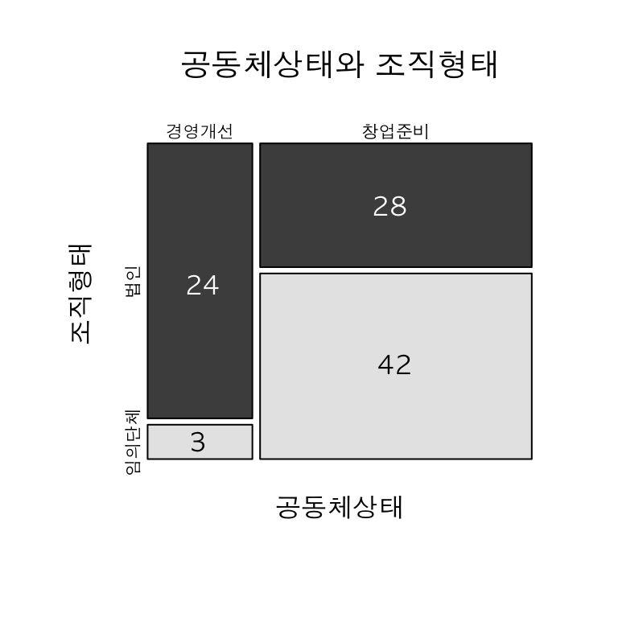

- 조직형태와 공동체상태
  - 이는 거꾸로 법인격을 갖춘 공동체사업체 중에 경영개선 상태에 들어간 비율이 압도적으로 많다는 것으로 이해할 수도 있음.

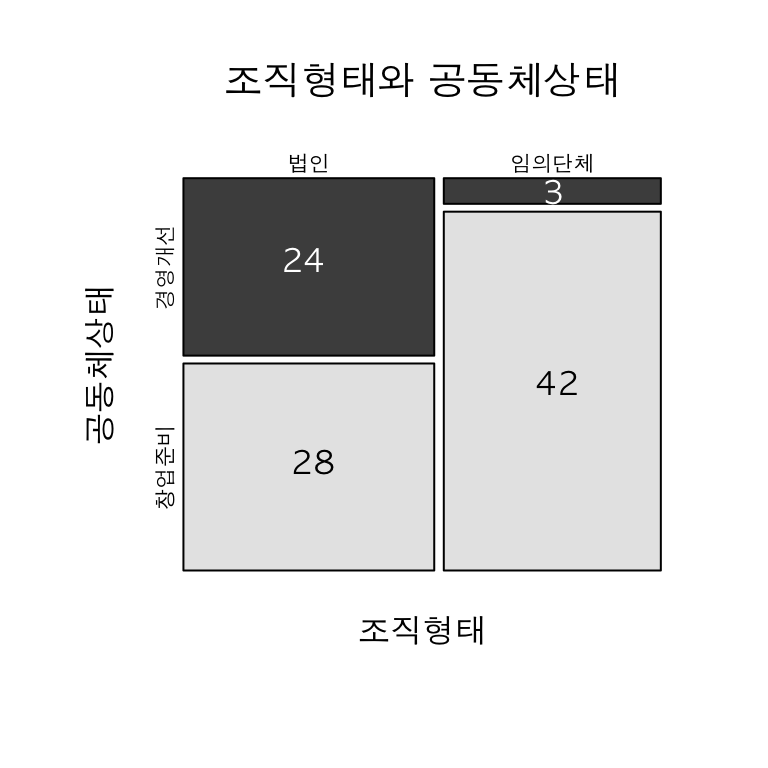

## 성장단계 구분에의 시사점

- 경영개선 상태의 법인 조직
  - 모두 사업에 착수하였고, 사업자등록도 마침. 매출도 대부분 발생

| 공동체상태 | 조직명 | 사업착수여부 | 사업자등록여부 | 2014년매출 | 2015년(3개월)매출 |
| --- | --- | --- | --- | --- | --- |
| 경영개선 | 이웃문화협동조합 | 착수 | 등록 | 0 | 7080 |
| 경영개선 | 수미마을 | 착수 | 등록 | 222200 | 0 |
| 경영개선 | 강릉수공예협동조합 | 착수 | 등록 | 2500 | 0 |
| 경영개선 | 도배마을 | 착수 | 등록 | 0 | 0 |
| 경영개선 | 콩메마루협동조합 | 착수 | 등록 | 70290 | 9900 |
| 경영개선 | 소치마을회 | 착수 | 등록 | 98837 | 23569 |
| 경영개선 | 하추영농조합 | 착수 | 등록 | 200000 | 33203 |
| 경영개선 | 아름다운인제관광 | 착수 | 등록 | 700000 | 2000 |
| 경영개선 | 화전민 | 착수 | 등록 | 150000 | 0 |
| 경영개선 | 누리마을빵카페 | 착수 | 등록 | 93300 | 20500 |
| 경영개선 | 탄지리꽃단지마을 | 착수 | 등록 | 31000 | 10200 |
| 경영개선 | 제천수상레저 | 착수 | 등록 | 54000 | 3000 |
| 경영개선 | 동편제영농조합법인 | 착수 | 등록 | 0 | 1300 |
| 경영개선 | 내일관광여행사협동조합 | 착수 | 등록 | 0 | 17000 |
| 경영개선 | 사랑골영농조합법인 | 착수 | 등록 | 0 | 0 |
| 경영개선 | 금오도영어영농조합 | 착수 | 등록 | 16000 | 2400 |
| 경영개선 | 에코도시락 | 착수 | 등록 | 15000 | 7500 |
| 경영개선 | 에코월드공정여행협동조합 | 착수 | 등록 | 0 | 6130 |
| 경영개선 | 고들빼기영농조합법인 | 착수 | 등록 | 0 | 0 |
| 경영개선 | 섬진강도깨비마을 | 착수 | 등록 | 156000 | 67444 |
| 경영개선 | 주왕산다원 | 착수 | 등록 | 57000 | 22900 |
| 경영개선 | 왕지등대마을 | 착수 | 등록 | 81137 | 3200 |
| 경영개선 | 꽃내마을 | 착수 | 등록 | 90000 | 0 |
| 경영개선 | 독일마을 | 착수 | 등록 | 18600 | 15600 |

- 경영개선 상태의 임의단체 조직
  - 임의단체인 경우가 소수 있으나 모두 사업에 착수하였고, 사업자등록도 마침. 모두 매출 발생

| 공동체상태 | 조직명 | 사업착수여부 | 사업자등록여부 | 2014년매출 | 2015년(3개월)매출 |
| --- | --- | --- | --- | --- | --- |
| 경영개선 | 왕피천아홉구비 | 착수 | 등록 | 40000 | 6500 |
| 경영개선 | 금강송마을 | 착수 | 등록 | 100000 | 12000 |
| 경영개선 | 두모마을 | 착수 | 등록 | 209000 | 3827 |

- 창업준비 상태의 법인 조직
  - 사업미착수는 39%, 사업자미등록이 32%에 달함. 매출 극히 일부 발생.

| 공동체상태 | 조직명 | 사업착수여부 | 사업자등록여부 | 2014년매출 | 2015년(3개월)매출 |
| --- | --- | --- | --- | --- | --- |
| 창업준비 | 양평펜션협동조합 | 미착수 | 미등록 | 0 | 0 |
| 창업준비 | 자연의소리들 | 미착수 | 미등록 | 0 | 0 |
| 창업준비 | 가평힐링가든 | 착수 | 미등록 | 0 | 4130 |
| 창업준비 | 재즈팜장아찌 | 착수 | 등록 | 0 | 6500 |
| 창업준비 | 에코피아가평발효팜협동조합 | 착수 | 미등록 | 0 | 8330 |
| 창업준비 | 공전자연학교 | 착수 | 등록 | 88100 | 27000 |
| 창업준비 | 교동민화마을 | 착수 | 등록 | 5400 | 1700 |
| 창업준비 | 성내리무암협동조합 | 착수 | 등록 | 12000 | 11000 |
| 창업준비 | 수산관광나들이 | 미착수 | 등록 | 0 | 0 |
| 창업준비 | 공주드림팜 | 착수 | 등록 | 0 | 4041 |
| 창업준비 | 남원사랑길협동조합 | 착수 | 등록 | 0 | 2300 |
| 창업준비 | 남원이색숙소체험협동조합 | 착수 | 등록 | 0 | 650 |
| 창업준비 | 남원공예드림협동조합 | 착수 | 등록 | 0 | 0 |
| 창업준비 | 벽골제마을주식회사 | 미착수 | 등록 | 0 | 0 |
| 창업준비 | 삶의향기공동체 | 착수 | 등록 | 0 | 0 |
| 창업준비 | 무주새내기 | 착수 | 미등록 | 0 | 7600 |
| 창업준비 | 남도곁꾼협동조합 | 착수 | 등록 | 0 | 0 |
| 창업준비 | 신흥영어영농조합 | 착수 | 등록 | 0 | 0 |
| 창업준비 | 동고지명품마을 | 착수 | 등록 | 0 | 2210 |
| 창업준비 | 버들인영농조합법인 | 미착수 | 등록 | 0 | 0 |
| 창업준비 | 두레아트 | 착수 | 등록 | 0 | 10000 |
| 창업준비 | 친환경영농조합법인 | 미착수 | 등록 | 0 | 0 |
| 창업준비 | 두실마을 | 미착수 | 미등록 | 0 | 0 |
| 창업준비 | 오전애권역 | 미착수 | 미등록 | 0 | 0 |
| 창업준비 | 다슬기마을 | 미착수 | 미등록 | 0 | 0 |
| 창업준비 | 대풍헌사람들 | 미착수 | 등록 | 0 | 0 |
| 창업준비 | 합천공예협동조합 | 착수 | 미등록 | 0 | 0 |
| 창업준비 | 고산송희망마을 | 미착수 | 등록 | 0 | 0 |

- 창업준비 상태의 임의단체 조직
  - 대부분 사업미착수(83%)이고, 사업자미등록(93%)인 상태임. 매출 극히 일부에서 발생하는 것으로 보고하고 있으나 개인사업자 명의의 실적임.

| 공동체상태 | 조직명 | 사업착수여부 | 사업자등록여부 | 2014년매출 | 2015년(3개월)매출 |
| --- | --- | --- | --- | --- | --- |
| 창업준비 | 수원누리 | 미착수 | 미등록 | 0 | 0 |
| 창업준비 | 수원화성공예_협 | 미착수 | 등록 | 0 | 0 |
| 창업준비 | 행궁맛촌 | 착수 | 미등록 | 0 | 20800 |
| 창업준비 | 마을과사람들 | 미착수 | 미등록 | 0 | 0 |
| 창업준비 | 양평카누레저 | 착수 | 등록 | 25450 | 0 |
| 창업준비 | 핸즈퍼니 | 미착수 | 미등록 | 0 | 0 |
| 창업준비 | 목화열애 | 미착수 | 미등록 | 0 | 0 |
| 창업준비 | 강릉도가 | 미착수 | 미등록 | 0 | 0 |
| 창업준비 | 영진리부녀회 | 미착수 | 미등록 | 0 | 0 |
| 창업준비 | 다림 | 미착수 | 미등록 | 0 | 4200 |
| 창업준비 | 공주곰돌빵 | 미착수 | 미등록 | 0 | 1620 |
| 창업준비 | 혼불문화예술촌협동조합 | 미착수 | 미등록 | 0 | 0 |
| 창업준비 | 남원문화기획사협동조합 | 미착수 | 미등록 | 0 | 0 |
| 창업준비 | 징게쟁이들 | 미착수 | 미등록 | 0 | 0 |
| 창업준비 | 손누리이야기 | 미착수 | 미등록 | 0 | 0 |
| 창업준비 | 무주음식연구회 | 미착수 | 미등록 | 0 | 0 |
| 창업준비 | 농촌살이아카데미 | 미착수 | 미등록 | 0 | 0 |
| 창업준비 | 덕유산차량이동서비스 | 미착수 | 미등록 | 0 | 0 |
| 창업준비 | 숲속나들이 | 착수 | 미등록 | 0 | 103000 |
| 창업준비 | 구천동펜션협의회 | 미착수 | 미등록 | 0 | 0 |
| 창업준비 | 여자만사람들 | 미착수 | 미등록 | 0 | 0 |
| 창업준비 | 수-레인보우 | 미착수 | 미등록 | 0 | 0 |
| 창업준비 | 청년창업집단수토리 | 착수 | 미등록 | 0 | 5000 |
| 창업준비 | 예그리나 | 미착수 | 미등록 | 0 | 0 |
| 창업준비 | 섬진강두꺼비 | 미착수 | 미등록 | 0 | 0 |
| 창업준비 | 심청약선마을 | 미착수 | 미등록 | 0 | 0 |
| 창업준비 | 미실란낭만부엌 | 미착수 | 미등록 | 0 | 0 |
| 창업준비 | 덕다헌 | 착수 | 미등록 | 12000 | 8328 |
| 창업준비 | 청송고택운영위원회 | 착수 | 미등록 | 176620 | 27470 |
| 창업준비 | 귀농투어사업단 | 미착수 | 미등록 | 0 | 0 |
| 창업준비 | 봉화도시락사업단 | 미착수 | 미등록 | 0 | 0 |
| 창업준비 | 협곡구비마을 | 미착수 | 미등록 | 0 | 0 |
| 창업준비 | 사미정펜션협의회 | 미착수 | 미등록 | 0 | 0 |
| 창업준비 | 오산항난전방티 | 미착수 | 미등록 | 0 | 0 |
| 창업준비 | 울진로컬푸드관광 | 미착수 | 미등록 | 0 | 0 |
| 창업준비 | 망양쪽빛바다 | 미착수 | 미등록 | 0 | 0 |
| 창업준비 | 울진기념품사업단 | 미착수 | 미등록 | 0 | 0 |
| 창업준비 | 보물섬다이아 | 미착수 | 미등록 | 0 | 1250 |
| 창업준비 | 남해펜션1번가 | 미착수 | 등록 | 0 | 0 |
| 창업준비 | 동행 | 착수 | 미등록 | 0 | 4275 |
| 창업준비 | 오토캠핑장사업자연합 | 미착수 | 미등록 | 0 | 0 |
| 창업준비 | 구평마을 | 미착수 | 미등록 | 0 | 0 |

### 3원 교차분석

- 공동체상태/조직형태와 사업자등록여부

|  |  | 사업자등록여부: | 등록 | 미등록 |
| --- | --- | --- | --- | --- |
| 공동체상태 : | 조직형태 : |  |  |  |
| 경영개선 | 법인 |  | 24 | 0 |
|  | 임의단체 |  | 3 | 0 |
| 창업준비 | 법인 |  | 19 | 9 |
|  | 임의단체 |  | 3 | 39 |

- 공동체상태/조직형태와 사업자등록여부(%)

|  |  | 사업자등록여부: | 등록 | 미등록 |
| --- | --- | --- | --- | --- |
| 공동체상태 : | 조직형태 : |  |  |  |
| 경영개선 | 법인 |  | 100.0 | 0.0 |
|  | 임의단체 |  | 100.0 | 0.0 |
| 창업준비 | 법인 |  | 67.9 | 32.1 |
|  | 임의단체 |  | 7.1 | 92.9 |

- 공동체상태/조직형태와 사업착수여부

[output not shown]

- 공동체상태/조직형태와 사업착수여부(%)

|  |  | 사업착수여부 : | 착수 | 미착수 |
| --- | --- | --- | --- | --- |
| 공동체상태 : | 조직형태 : |  |  |  |
| 경영개선 | 법인 |  | 100.0 | 0.0 |
|  | 임의단체 |  | 100.0 | 0.0 |
| 창업준비 | 법인 |  | 60.7 | 39.3 |
|  | 임의단체 |  | 16.7 | 83.3 |

## 공동체상태와 법인유형

### 교차표

<공동체상태와 조직유형>

|  | 마을회 | 사단법인 | 영농조합법인 | 유한회사 | 임의단체 | 주식회사 | 협동조합 |
| --- | --- | --- | --- | --- | --- | --- | --- |
| 경영개선 | 1 | 2 | 13 | 1 | 2 | 3 | 5 |
| 창업준비 | 0 | 3 | 9 | 0 | 42 | 2 | 14 |

<주식회사인 공동체사업체>

|  | 공동체상태 | 조직명 |
| --- | --- | --- |
| 22 | 경영개선 | 아름다운인제관광 |
| 30 | 경영개선 | 제천수상레저 |
| 42 | 창업준비 | 벽골제마을주식회사 |
| 56 | 창업준비 | 동고지명품마을 |
| 59 | 경영개선 | 에코도시락 |

### 모자이크 플롯

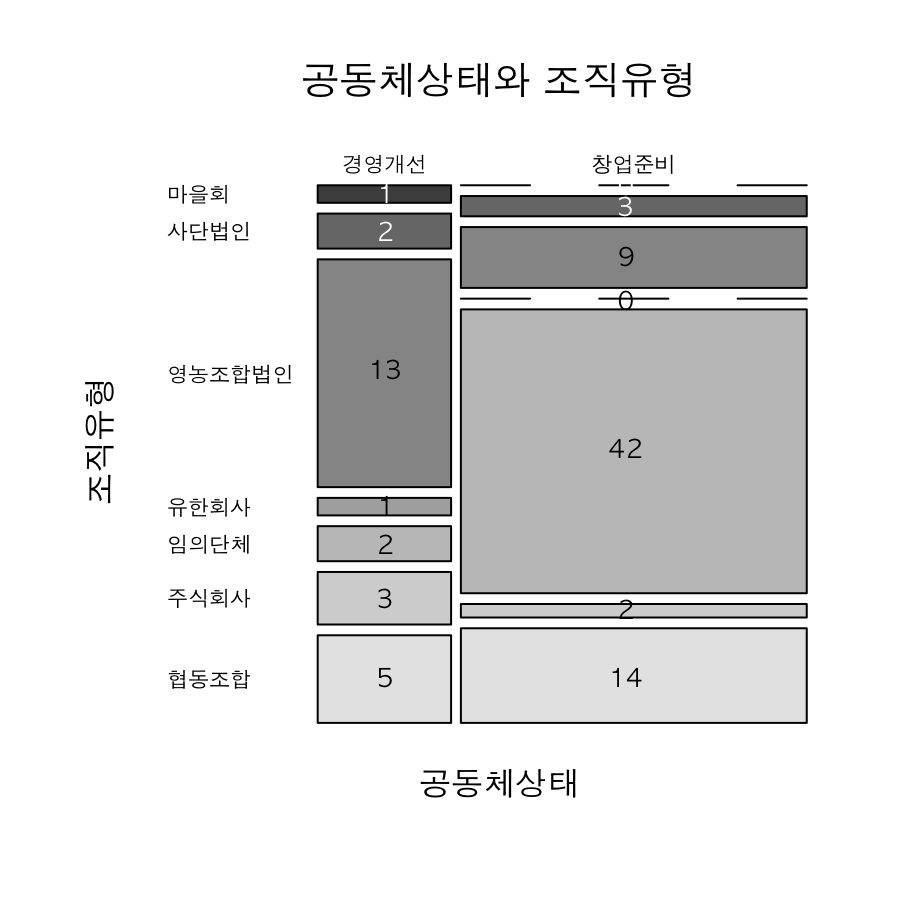

## 공동체상태와 사업아이템

### 교차표(개소수)

- 경영개선 상태에서는 ‘식음’과 ’체험’, 창업준비 상태에서는 ’식음’과 ’관광기념품’이 많이 있음.

<공동체상태와 사업아이템>

|  | 관광기념품 | 교통 | 레저스포츠 | 숙박 | 식음 | 주민여행사 | 체험 | 계 |
| --- | --- | --- | --- | --- | --- | --- | --- | --- |
| 경영개선 | 1 | 0 | 4 | 1 | 10 | 2 | 9 | 27 |
| 창업준비 | 13 | 1 | 4 | 10 | 20 | 10 | 12 | 70 |

### 교차표(%)

- 창업준비 상태에서 ’관광기념품’의 비중이 매우 높음.

<공동체상태와 사업아이템(%)>

|  | 관광기념품 | 교통 | 레저스포츠 | 숙박 | 식음 | 주민여행사 | 체험 | 계 |
| --- | --- | --- | --- | --- | --- | --- | --- | --- |
| 경영개선 | 3.7 | 0.0 | 14.8 | 3.7 | 37.0 | 7.4 | 33.3 | 100 |
| 창업준비 | 18.6 | 1.4 | 5.7 | 14.3 | 28.6 | 14.3 | 17.1 | 100 |

### 모자이크 플롯

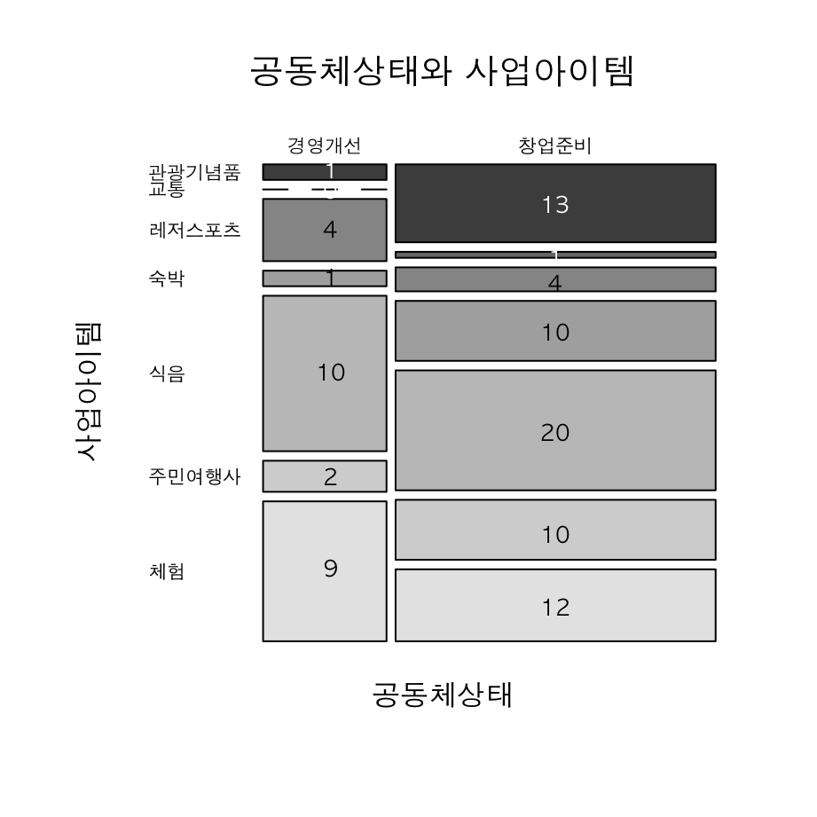

## 공동체상태와 업력

### 요약표

- **경영개선**:

  | Min. | 1st Qu. | Median | Mean | 3rd Qu. | Max. |
  | --- | --- | --- | --- | --- | --- |
  | 1.4 | 2.65 | 4.5 | 4.99 | 6.2 | 12.5 |

- **창업준비**:

  | Min. | 1st Qu. | Median | Mean | 3rd Qu. | Max. |
  | --- | --- | --- | --- | --- | --- |
  | 0.2 | 1 | 1.5 | 1.69 | 1.6 | 11.8 |

### Box Plot

- 공동체 상태별 5숫자 요약 및 이상점 파악
  - ’아름다운인제관광’과 ’예그리나’가 예외적으로 오랜 업력

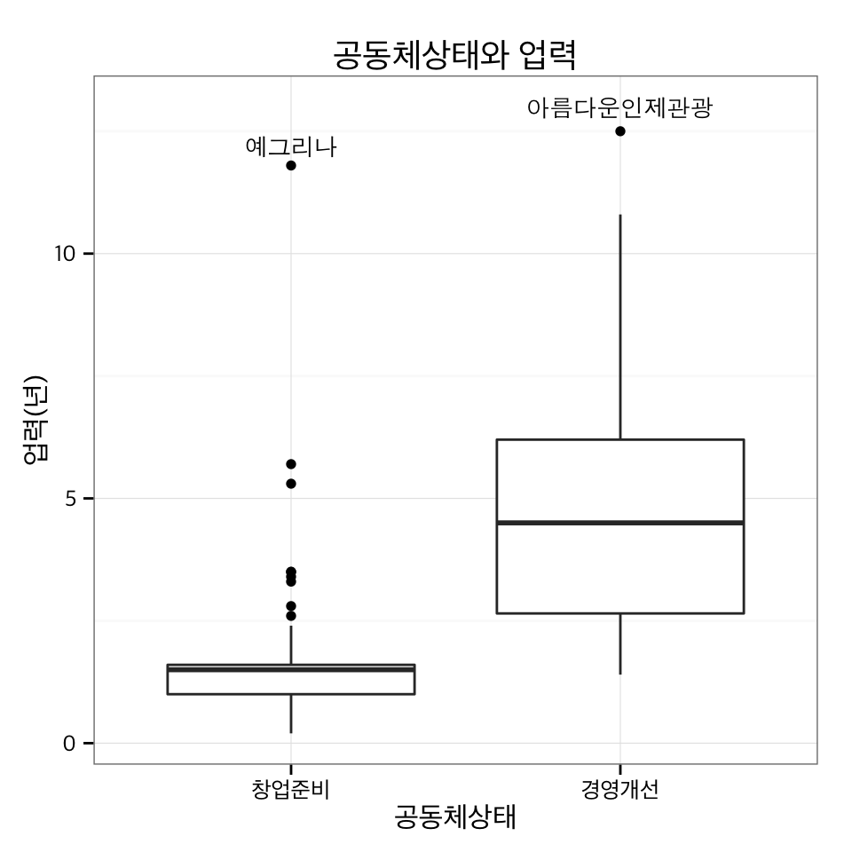

### ECDF

- 분위수 비교 뿐 아니라 평균 업력 비교도 가능함

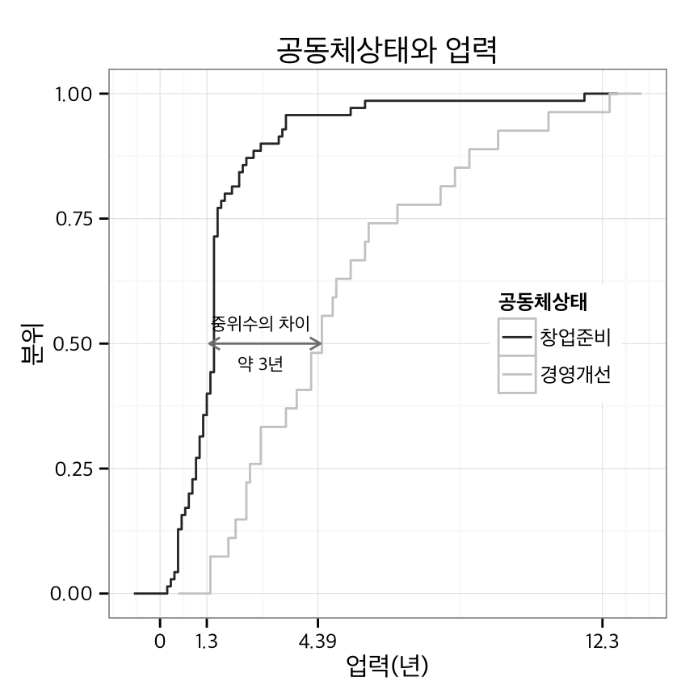

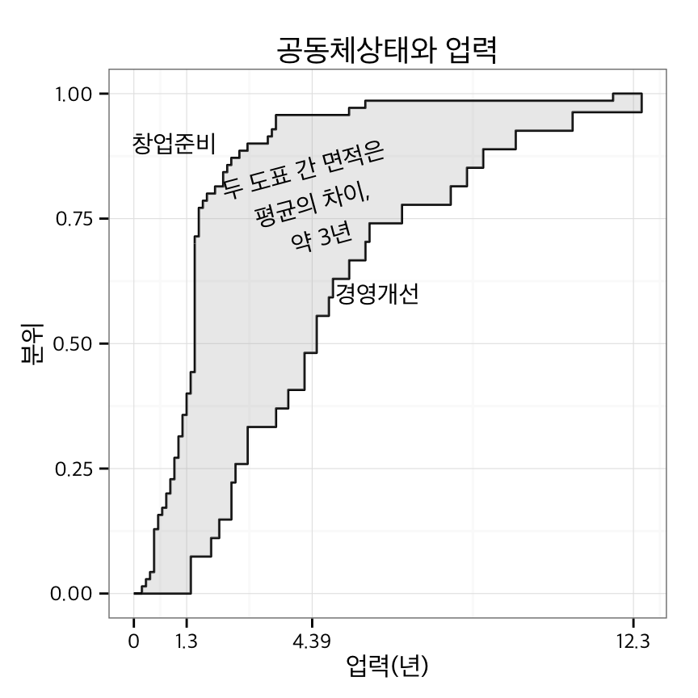

### Dot Chart

- 전체 주민공동체사업의 업력을 공동체상태별로 한눈에 비교
  - 개별 조직명도 파악됨.

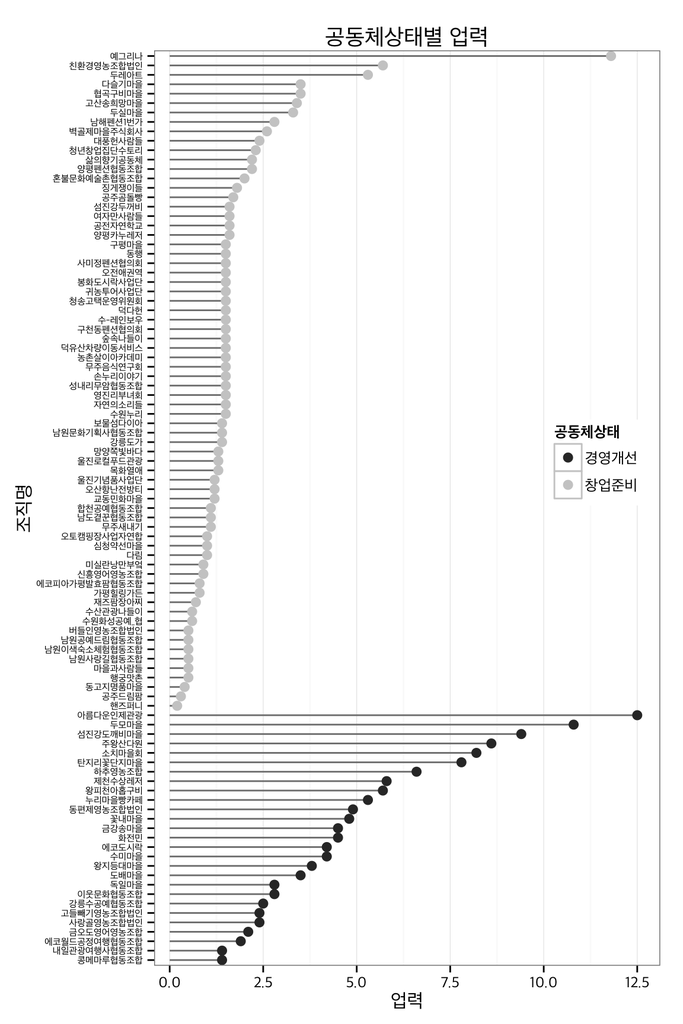

## 방문객과 매출 요약

### 공동체상태별 평균 비교

| 공동체상태 | 방문객(2014) | 방문객(2015, 3개월) | 매출(2014) | 매출(2015, 3개월) |
| --- | --- | --- | --- | --- |
| 경영개선 | 35030 | 1756 | 89069 | 10195 |
| 창업준비 | 245 | 291 | 4565 | 3734 |

### 공동체상태별 중위수 비교

| 공동체상태 | 방문객(2014) | 방문객(2015, 3개월) | 매출(2014) | 매출(2015, 3개월) |
| --- | --- | --- | --- | --- |
| 경영개선 | 3477 | 870 | 54000 | 6130 |
| 창업준비 | 0 | 0 | 0 | 0 |

## 방문객 및 매출 상위 조직

### 방문객(2014)

| 공동체상태 | 조직명 | 방문객(2014) |
| --- | --- | --- |
| 경영개선 | 독일마을 | 800000 |
| 경영개선 | 에코도시락 | 28000 |
| 경영개선 | 금강송마을 | 17000 |
| 경영개선 | 아름다운인제관광 | 15000 |
| 경영개선 | 두모마을 | 13896 |
| 경영개선 | 수미마을 | 10560 |
| 경영개선 | 누리마을빵카페 | 8220 |
| 경영개선 | 하추영농조합 | 7234 |
| 경영개선 | 왕지등대마을 | 6511 |
| 경영개선 | 강릉수공예협동조합 | 6050 |
| 경영개선 | 꽃내마을 | 5800 |
| 창업준비 | 공전자연학교 | 5460 |
| 창업준비 | 청송고택운영위원회 | 5384 |
| 경영개선 | 화전민 | 5000 |
| 경영개선 | 주왕산다원 | 3800 |
| 경영개선 | 콩메마루협동조합 | 3477 |
| 경영개선 | 제천수상레저 | 3400 |
| 경영개선 | 소치마을회 | 3358 |
| 경영개선 | 탄지리꽃단지마을 | 3154 |
| 경영개선 | 왕피천아홉구비 | 3000 |

### 방문객(2015, 3개월)

| 공동체상태 | 조직명 | 방문객(2015, 3개월) |
| --- | --- | --- |
| 경영개선 | 두모마을 | 10154 |
| 경영개선 | 왕지등대마을 | 8300 |
| 경영개선 | 섬진강도깨비마을 | 7609 |
| 경영개선 | 내일관광여행사협동조합 | 6600 |
| 창업준비 | 행궁맛촌 | 5200 |
| 창업준비 | 남원사랑길협동조합 | 2950 |
| 창업준비 | 숲속나들이 | 2210 |
| 경영개선 | 누리마을빵카페 | 2100 |
| 경영개선 | 에코월드공정여행협동조합 | 2095 |
| 경영개선 | 하추영농조합 | 1823 |
| 창업준비 | 성내리무암협동조합 | 1300 |
| 창업준비 | 공전자연학교 | 1200 |
| 경영개선 | 왕피천아홉구비 | 1200 |
| 경영개선 | 주왕산다원 | 1170 |
| 창업준비 | 무주새내기 | 1120 |
| 창업준비 | 남원이색숙소체험협동조합 | 1100 |
| 경영개선 | 동편제영농조합법인 | 1100 |
| 창업준비 | 교동민화마을 | 1080 |
| 경영개선 | 아름다운인제관광 | 1000 |
| 경영개선 | 금강송마을 | 1000 |

### 매출(2014)

| 공동체상태 | 조직명 | 매출(2014) |
| --- | --- | --- |
| 경영개선 | 아름다운인제관광 | 700000 |
| 경영개선 | 수미마을 | 222200 |
| 경영개선 | 두모마을 | 209000 |
| 경영개선 | 하추영농조합 | 200000 |
| 창업준비 | 청송고택운영위원회 | 176620 |
| 경영개선 | 섬진강도깨비마을 | 156000 |
| 경영개선 | 화전민 | 150000 |
| 경영개선 | 금강송마을 | 100000 |
| 경영개선 | 소치마을회 | 98837 |
| 경영개선 | 누리마을빵카페 | 93300 |
| 경영개선 | 꽃내마을 | 90000 |
| 창업준비 | 공전자연학교 | 88100 |
| 경영개선 | 왕지등대마을 | 81137 |
| 경영개선 | 콩메마루협동조합 | 70290 |
| 경영개선 | 주왕산다원 | 57000 |
| 경영개선 | 제천수상레저 | 54000 |
| 경영개선 | 왕피천아홉구비 | 40000 |
| 경영개선 | 탄지리꽃단지마을 | 31000 |
| 창업준비 | 양평카누레저 | 25450 |
| 경영개선 | 독일마을 | 18600 |

### 매출(2015, 3개월)

| 공동체상태 | 조직명 | 매출(2015, 3개월) |
| --- | --- | --- |
| 창업준비 | 숲속나들이 | 103000 |
| 경영개선 | 섬진강도깨비마을 | 67444 |
| 경영개선 | 하추영농조합 | 33203 |
| 창업준비 | 청송고택운영위원회 | 27470 |
| 창업준비 | 공전자연학교 | 27000 |
| 경영개선 | 소치마을회 | 23569 |
| 경영개선 | 주왕산다원 | 22900 |
| 창업준비 | 행궁맛촌 | 20800 |
| 경영개선 | 누리마을빵카페 | 20500 |
| 경영개선 | 내일관광여행사협동조합 | 17000 |
| 경영개선 | 독일마을 | 15600 |
| 경영개선 | 금강송마을 | 12000 |
| 창업준비 | 성내리무암협동조합 | 11000 |
| 경영개선 | 탄지리꽃단지마을 | 10200 |
| 창업준비 | 두레아트 | 10000 |
| 경영개선 | 콩메마루협동조합 | 9900 |
| 창업준비 | 에코피아가평발효팜협동조합 | 8330 |
| 창업준비 | 덕다헌 | 8328 |
| 창업준비 | 무주새내기 | 7600 |
| 경영개선 | 에코도시락 | 7500 |

### 자료 갈무리

```r
doorae0928 <- doorae
save.image("doorae_new.rda")
```